# Procesamiento base de imágenes satelitales con Python

### Práctico de transferencia radiativa (Modelo Directo)

```
       Elaborado por Franco Ompré 2019
       Revisado por Sebastián Heredia 2020
```

El objetivo del práctico es poder setear un conjunto de variables que nos permitan calcular la radiación a tope de atmósfera para un dado escenario utilizando el Modelo de Transferencia Radiativa 6S.

Para conocer la radiación a TOA (Top Of Atmosphere) necesitamos fijar un conjunto de parámetros que caractericen la escena observada.

El 6S es un código escrito en lenguaje Fortran 77 por lo que vamos a utilizar una libreria de python llamada **Py6s** que nos sirve de interfaz con el 6S permitiendonos acceder a la configuración del modelo de transferencia radiativa de forma mas simple.

Necesitamos configurar el siguiente conjunto de parámetros:

```
- Geometria de observación:
    - Altitud de observador
    - Altitud del blanco
    - Ángulos de observación del blanco.
    - Angulos de iluminación del blanco.

- Condiciones Atmosféricas:
    - AOT (Aerosol optical thickness)
    - Aero Profile
    - Atmospheric profile
    - Atmospheric correction

- Superficie
```

Luego de tener seteados los parametros para la simulación resta correr el Py6s. Al utilizar el comando run el Py6s genera un archivo de texto, el cual, es el input del 6S. Al ejecutarse el 6S, su output es un archivo de texto que contiene las variables de salida (ej: radiacia del pixel a TOA), las cuales son importadas e interpretado por el Py6s (para más información, consultar: RWilson_20200508_Py6S.pdf)

A continuación se mostrarán diferentes configuraciones para ejecutar el 6S via el Py6S.

```python
#%matplotlib notebook
# Importamos las librerias necesarias.
from Py6S import *
from matplotlib import pyplot as plt
import numpy as np
import os as os
```

```python
import sys
print(sys.executable)
print(sys.version)
print(sys.version_info)
```

```
C:\Users\marti\anaconda3\envs\pis2022\python.exe
3.9.7 (default, Sep 16 2021, 16:59:28) [MSC v.1916 64 bit (AMD64)]
sys.version_info(major=3, minor=9, micro=7, releaselevel='final', serial=0)
```

Probamos que 6S haya sido bien instalado

Ejecutar la celda siguiente. La salida de la misma debería ser:

6S wrapper script by Robin Wilson

Using 6S located at /home/Sergio/anaconda3/envs/py6s-env/bin/sixs

Running 6S using a set of test parameters

6sV version: 1.1

The results are:

Expected result: 619.158000

Actual result: 619.158000

#### Results agree, Py6S is working correctly

0

```python
# Creamos un objeto que va a ser la simulación al cual le podemos pasar parámetros.
print('El objeto s nos permite acceder a los métodos del 6S')

s = SixS()
# Ver atributos de un objeto.
# vars(s)
```

```
El objeto s nos permite acceder a los métodos del 6S
```

```python
s.test()
```

```
6S wrapper script by Robin Wilson
Using 6S located at C:\Users\marti\anaconda3\envs\pis2022\Library\bin\sixs.exe
Running 6S using a set of test parameters
6sV version: 1.1
The results are:
Expected result: 619.158000
Actual result: 619.158000
#### Results agree, Py6S is working correctly
```

```
0
```

- Definimos geometria de observación:
  - Altitud del satélite
  - Ángulos de observación de la superficie
  - Angulos de iluminación de la superficie

```python
# Se especifica la altura del sensor
s.altitudes.set_sensor_satellite_level()

# Se especifica la altura del escenario
s.altitudes.set_target_sea_level()

print('Fijamos la posición del sol y del ángulo azimutal del sensor. Para ello elija la opción deseada \
y comente la otra')

# Opción 1 : Fijando el ángulo de visión y del sol el mes y el día.\n
s.geometry.view_a = 0 # angulo del sensor en asimut
s.geometry.view_z = 45 # ang sensor en zenit
s.geometry.solar_z= 225 # Lo mismo para el sol, angulo de iluminacion.
s.geometry.solar_a = 180
s.geometry.day = 24 # Dia y mes para correccion orbital, por exentricidad de la orbita, posicion del sol... K
s.geometry.month = 6

# Opción 2 : Colocando la latitud y posicion del pixel y la hora aproximada de toma de la imagen
# s.geometry.from_time_and_location(pixel_latitud,pixel_longitud,"01/08/2011 9:27:52.8000",pixel_view_zenith,pixel_view_azimuth)
```

```
Fijamos la posición del sol y del ángulo azimutal del sensor. Para ello elija la opción deseada y comente la otra
```

- Definimos condiciones Atmosféricas:
  - AOT (*Aerosol optical thickness*)
  - Aero Profile
  - Atmospheric profile
  - Atmospheric correction

El AOT es un parámetro muy importante a tener en cuenta. Puede probar su influencia haciendolo variar en un rango ámplio.

```python
# Cada parametro hay que estudiarlo para ver que significa, voy a definir un perfil de aerosoles maritimos.

# Se especifica el tipo de aerosoles presentes
s.aero_profile = AeroProfile.PredefinedType(AeroProfile.Maritime)
s.aot550 = 0.07

# se especifica el tipo de perfil de atmosfera
s.atmos_profile = AtmosProfile.PredefinedType(AtmosProfile.Tropical)

# Otra opción para definir el perfil atmosférico
# s.atmos_profile = AtmosProfile.FromLatitudeAndDate(pixel_latitude,"24/06/2011")

# No realizamos correcion atmosférica
s.atmos_corr = AtmosCorr.NoAtmosCorr()
```

### Generamos las condiciones de suelo.

El 6S posee un rango amplio de modelos de superficies que pueden ser simuladas. La BRDF es computada de una forma distinta para cada una.

Se podria parametrizar la superficie y analizar el comportamieto para cada corrida.

```python
print('Creamos la superficie')
# wind_speed = 5
# angle_wind = 10
# s.ground_reflectance  = GroundReflectance.HomogeneousOcean(0,100,-1,0.6)
s.ground_reflectance  = GroundReflectance.HomogeneousLambertian(GroundReflectance.LakeWater) # es un lakewater
```

```
Creamos la superficie
```

## Elección de la banda deseada

Py6s posee una versatilidad en cuanto a la selección de la banda de observación. Se pueden seleccionar bandas pertenecientes a distintos sensores satelitales como LANDSAT, MERIS, etc. O bien se puede especificar la longitud de onda a observar, o aún más, aparte de seleccionar la banda se le puede indicar la función respuesta espectral.

```python
print("""---------------Hasta aca  generamos las condiciones iniciales de la corrida--------------------""")
print("""Solo resta definir en que longitud de onda o en que rango de longitudes de onda correr el 6S.\n
Para esto hay dos opciones:
    -si solo es para una longitud de onda comente la linea del sixhelper\n
    -si es para todas las bandas del meris comente el s.run y el tipo de longitud de onda a utilizar""")
#    wavelengths, values = SixSHelpers.Wavelengths.run_meris(s, output_name='apparent_radiance')

"""Fijamos la longitud de onda. Las bandas correspondientes a meris son:
    - 412.691 nm que corrresponde a la banda1
    - 442.55902 nm que corrresponde a la banda2
    - 489.88202 nm que corrresponde a la banda3
    - 509.81903 nm que corrresponde a la banda4
    - 559.69403 nm que corrresponde a la banda5
    - 619.601   nm que corrresponde a la banda6
    - 664.57306 nm que corrresponde a la banda7
    - 680.82104 nm que corrresponde a la banda8
    - 708.32904 nm que corrresponde a la banda9
    - 753.37103 nm que corrresponde a la banda10
    - 761.50806 nm que corrresponde a la banda11
    - 778.40906 nm que corrresponde a la banda12
    - 864.87604 nm que corrresponde a la banda13
    - 884.94403 nm que corrresponde a la banda14
    - 900.00006 nm que corrresponde a la banda15
    """

# Aqui se encuentran las 3 opciones comentadas en el encabezado. Descomente la que desea''')
# s.wavelength = Wavelength(0.550,0.5500001)
s.wavelength = Wavelength(PredefinedWavelengths.MERIS_B3)
# s.wavelength =  Wavelength(0.400, 0.410, [0.7, 0.9, 1.0, 0.3, 0.15])
```

```
---------------Hasta aca  generamos las condiciones iniciales de la corrida--------------------
Solo resta definir en que longitud de onda o en que rango de longitudes de onda correr el 6S.

Para esto hay dos opciones:
    -si solo es para una longitud de onda comente la linea del sixhelper

    -si es para todas las bandas del meris comente el s.run y el tipo de longitud de onda a utilizar
```

## Iniciamos la simulación

```python
s.run()
```

### Visualización en Pantalla del archivo de texto devuelto por 6S

```python
print(s.outputs.fulltext)
```

```
******************************* 6SV version 1.1 *******************************
*                                                                             *
*                       geometrical conditions identity                       *
*                       -------------------------------                       *
*                       user defined conditions                               *
*                                                                             *
*   month:  6 day :  24                                                       *
*   solar zenith angle:  225.00 deg  solar azimuthal angle:      180.00 deg   *
*   view zenith angle:    45.00 deg  view azimuthal angle:         0.00 deg   *
*   scattering angle:      0.02 deg  azimuthal angle difference: 180.00 deg   *
*                                                                             *
*                       atmospheric model description                         *
*                       -----------------------------                         *
*           atmospheric model identity :                                      *
*               tropical            (uh2o=4.12g/cm2,uo3=.247cm-atm)           *
*           aerosols type identity :                                          *
*               Maritime aerosol model                                        *
*           optical condition identity :                                      *
*               visibility : 99.49 km  opt. thick. 550 nm :  0.0700           *
*                                                                             *
*                       spectral condition                                    *
*                       ------------------                                    *
*           meris   3                                                         *
*               value of filter function :                                    *
*                wl inf= 0.480 mic   wl sup= 0.498 mic                        *
*                                                                             *
*                       Surface polarization parameters                       *
*                       ----------------------------------                    *
*                                                                             *
*                                                                             *
* Surface Polarization Q,U,Rop,Chi    0.00000  0.00000  0.00000     0.00      *
*                                                                             *
*                                                                             *
*                       target type                                           *
*                       -----------                                           *
*           homogeneous ground                                                *
*             spectral lake water reflectance        0.075                    *
*                                                                             *
*                       target elevation description                          *
*                       ----------------------------                          *
```

[output cut: 78 more lines]

```
*      optical depth total:     0.15768        0.07261        0.23029         *
*      optical depth plane:     0.15768        0.07261        0.23029         *
*      reflectance I      :    -0.14456       -9.13746       -9.30103         *
*      reflectance Q      :    -0.00347       -0.00003       -0.00403         *
*      reflectance U      :     0.00000        0.00000        0.00000         *
*      polarized reflect. :     0.00347        0.00003        0.00403         *
*      degree of polar.   :       -2.40          -0.00          -0.04         *
*      dir. plane polar.  :        0.00           0.00           0.00         *
*      phase function I   :     1.47936       ********       ********         *
*      phase function Q   :    -0.00000        0.00003        0.00001         *
*      phase function U   :     1.43809       ********       ********         *
*      primary deg. of pol:    -0.00000        0.00000        0.00000         *
*      sing. scat. albedo :     1.00000        0.98971        0.99676         *
*                                                                             *
*                                                                             *
```

Otra forma de ver los outputs como atributos de un objeto

```python
print(s.outputs.values)
```

```
{'version': '1.1', 'month': 6, 'day': 24, 'solar_z': 225, 'solar_a': 180, 'view_z': 45, 'view_a': 0, 'scattering_angle': 0.02, 'azimuthal_angle_difference': 180.0, 'visibility': 99.49, 'aot550': 0.07, 'ground_pressure': 1013.0, 'ground_altitude': 0.0, 'apparent_reflectance': -9.2181425, 'apparent_ra…
```

### Lectura de outputs

En la primer parte del código se crean listas mudas en las que se van a agrupar los valores correspondientes a las variables de salida. En la segunda, se cargan los valores de la variables en las listas correspondientes.

```python
# Primer Parte: definición de listas:
print('Irradiancias')
direct_solar_irradiance = []
environmental_irradiance = []
diffuse_solar_irradiance = []
#solar_spectrum = []
print('Reflectancias')
pixel_reflectance = []
sunglint_reflectance = []
seawater_reflectance = []
foam_reflectance = []
apparent_reflectance = []
print('Radiancias')
apparent_radiance = []
pixel_radiance = []
atmospheric_intrinsic_radiance = []
background_radiance = []

print('s.outputs',s.outputs)
print('s',s)

# Segunda Parte: carga de valores a las listas
print('Vamos guardando los diferentes outputs. Esta opcion solo es valida cuando no usamos el sixhelper. \
Si se usa el sixhelper comentar esta parte del codigo')
print('Irradiancias')
direct_solar_irradiance = np.append(direct_solar_irradiance , s.outputs.direct_solar_irradiance)
environmental_irradiance = np.append(environmental_irradiance , s.outputs.environmental_irradiance)
diffuse_solar_irradiance = np.append(diffuse_solar_irradiance , s.outputs.diffuse_solar_irradiance)
#    solar_spectrum = np.append(solar_spectrum )
print('Reflectancias')
apparent_reflectance = np.append(apparent_reflectance , s.outputs.apparent_reflectance)
pixel_reflectance = np.append(pixel_reflectance , s.outputs.pixel_reflectance)
# sunglint_reflectance = np.append(sunglint_reflectance , s.outputs.sunglint_reflectance)
# seawater_reflectance = np.append(seawater_reflectance , s.outputs.seawater_reflectance)
# foam_reflectance = np.append(foam_reflectance , s.outputs.foam_reflectance)
print('Radiancias')
apparent_radiance = np.append(apparent_radiance,s.outputs.apparent_radiance)
pixel_radiance = np.append(pixel_radiance , s.outputs.pixel_radiance)
atmospheric_intrinsic_radiance = np.append(atmospheric_intrinsic_radiance,s.outputs.atmospheric_intrinsic_radiance)
background_radiance = np.append(background_radiance,s.outputs.background_radiance)
```

```
Irradiancias
Reflectancias
Radiancias
s.outputs <Py6S.outputs.Outputs object at 0x00000258C8E4EBB0>
s <Py6S.sixs.SixS object at 0x00000258B0AC8F10>
Vamos guardando los diferentes outputs. Esta opcion solo es valida cuando no usamos el sixhelper. Si se usa el sixhelper comentar esta parte del codigo
Irradiancias
Reflectancias
Radiancias
```

# Simulaciones con variación de Parámetros

A continuación definimos las variables que se mantendrán constantes en la simulación

```python
# Se especifica el tipo de escenario
s.ground_reflectance = GroundReflectance.HomogeneousLambertian(GroundReflectance.LakeWater)
# El siguiente escenario es para el caso de superficie marina
#s.ground_reflectance = GroundReflectance.HomogeneousOcean(5,5,10,10) #HomogeneousOcean(wind_speed, wind_azimuth, salinity, pigment_concentration)

# se especifica el tipo de perfil de atmosfera
s.atmos_profile = AtmosProfile.PredefinedType(AtmosProfile.MidlatitudeSummer)

# No realizamos correcion atmosferica
s.atmos_corr = AtmosCorr.NoAtmosCorr()
```

```python
print('Configuramos la geometria del sensor, asi como su altura y la del\
 blanco')

# Geometria de observación del sensor  datetime format: YYYY-MM-DD HH:MM:SS
s.geometry.from_time_and_location(51.148, 0.307, "2022-05-23 10:00:00", 0, 10) # from_time_and_location(lat,long,datetimestring,view_z,view_a)


# Se especifica la altura del sensor
s.altitudes.set_sensor_satellite_level()

# Se especifica la altura del escenario
s.altitudes.set_target_sea_level()
```

```
Configuramos la geometria del sensor, asi como su altura y la del blanco
```

### Variación del tipo de aerosoles

```
Corremos para distintos perfiles de aerosoles predefinidos en todo el vnir     rango de las fracuencia del 6S
AeroProfile.Maritime
Running for many wavelengths - this may take a long time
AeroProfile.Maritime
AeroProfile.Continental
Running for many wavelengths - this may take a long time
AeroProfile.Continental
AeroProfile.BiomassBurning
Running for many wavelengths - this may take a long time
AeroProfile.BiomassBurning
AeroProfile.NoAerosols
Running for many wavelengths - this may take a long time
AeroProfile.NoAerosols
```

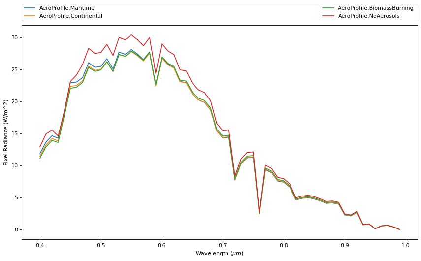

```python
print('Corremos para distintos perfiles de aerosoles predefinidos en todo el vnir \
    rango de las fracuencia del 6S')


# Se especifica el tipo de aerosoles presentes
predifinedtype = [AeroProfile.Maritime , AeroProfile.Continental , AeroProfile.BiomassBurning , AeroProfile.NoAerosols]
nameprofile = ['AeroProfile.Maritime' , 'AeroProfile.Continental ', 'AeroProfile.BiomassBurning ', 'AeroProfile.NoAerosols']
i = 0
for param in predifinedtype :

    print(nameprofile[i])
    s.aero_profile = AeroProfile.PredefinedType(param)
    wavelengths, results = SixSHelpers.Wavelengths.run_wavelengths(s, np.arange(0.4, 1., 0.01), output_name='pixel_radiance')
    labels = nameprofile[i]
    print(nameprofile[i])
    plt.figure(1,figsize=(18*(.72), 10*(.72)), dpi= 80, facecolor='w', edgecolor='k')
    plt.plot(wavelengths, results,  label =labels )
    plt.legend(bbox_to_anchor=(0., 1.02, 1., .102), loc=3, ncol=2, mode="expand", borderaxespad=0.)
    plt.xlabel("Wavelength ($\mu m$)")
    plt.ylabel("Pixel Radiance (W/m^2)")
    i = i+1
plt.show()
```

Tenemos informacion para todo un rango de longitud de onda. Espectro,

### Variación de la columna de vapor de agua

```
Seteamos variables que se van a mantener constantes en la simulación
Configuramos la geometria del sensor, asi como su altura y la del blanco
Corremos para distintos perfiles atmosféricos cambiando la cantidad de vapor de agua en la atmosfera
Con la clase: UserWaterAndOzone(Columna de Vapor de Agua,Ozono) se define el tipo de atmósfera
La cantidad tipica de columna de vapor de agua varía entre 6.5 y 180 kg/m^2. El ozono se va a fijar en su valor medio de 5.3 g/m^2
En el siguiente for, variaremos la columna de vapor de agua entre 6.5 y 180 kg/m^2 con pasos de 15 kg/m^2.
6.5  kg/m^2 of water
Running for many wavelengths - this may take a long time
81.5  kg/m^2 of water
Running for many wavelengths - this may take a long time
```

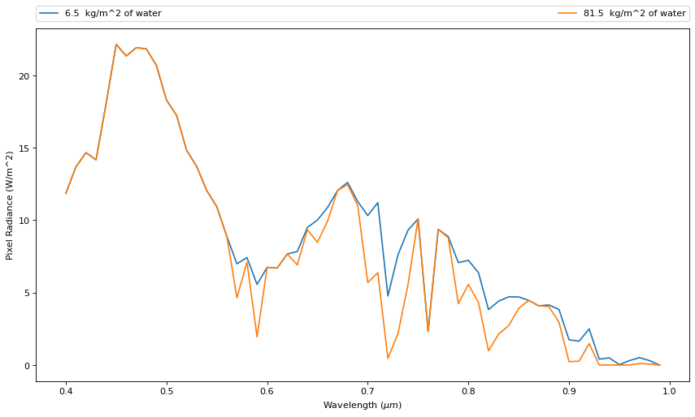

```python
print('Seteamos variables que se van a mantener constantes en la simulación')
#------------------------------------------------------------------------------
# Se especifica el tipo de aerosoles presentes
s.aero_profile = AeroProfile.PredefinedType(AeroProfile.Maritime)

# Se especifica el tipo de superficie
s.ground_reflectance = GroundReflectance.HomogeneousLambertian(GroundReflectance.LakeWater)
#s.ground_reflectance = GroundReflectance.HomogeneousOcean(5,5,10,10)

# No realizamos correcion atmosferica
s.atmos_corr = AtmosCorr.NoAtmosCorr()
#------------------------------------------------------------------------------

#==============================================================================
print('Configuramos la geometria del sensor, asi como su altura y la del\
 blanco')

# Geometria de observación del sensor
s.geometry.from_time_and_location(51.148, 0.307, "2022-05-23 10:00:00", 0, 10) # from_time_and_location(lat,long,datetimestring,view_z,view_a)

# Se especifica la altura del sensor
s.altitudes.set_sensor_satellite_level()

# Se especifica la altura del escenario
s.altitudes.set_target_sea_level()


print('Corremos para distintos perfiles atmosféricos cambiando la cantidad de vapor\
 de agua en la atmosfera')
print('Con la clase: UserWaterAndOzone(Columna de Vapor de Agua,Ozono) se define el tipo de atmósfera')
print('La cantidad tipica de columna de vapor de agua varía entre 6.5 y 180 kg/m^2. El ozono se va a fijar en\
 su valor medio de 5.3 g/m^2')
print('En el siguiente for, variaremos la columna de vapor de agua entre 6.5 y 180 kg/m^2 con pasos de 15\
 kg/m^2.')

# for j in np.arange(0,10,1):
for j in [0,5]:
    delta=15
    labels = str(j*delta+6.5)+"  kg/m^2 of water"
    print (labels)
    s.atmos_profile = AtmosProfile.UserWaterAndOzone(6.5+j*delta,5.3)
    wavelengths, results = SixSHelpers.Wavelengths.run_wavelengths(s, np.arange(0.4, 1., 0.01), output_name='pixel_radiance')

    plt.figure(3,figsize=(18*(.72), 10*(.72)), dpi= 80, facecolor='w', edgecolor='k')
    plt.plot(wavelengths, results,  label =labels )
    plt.legend(bbox_to_anchor=(0., 1.02, 1., .102), loc=3, ncol=2, mode="expand", borderaxespad=0.)
    plt.xlabel("Wavelength ($\mu m$)")
    plt.ylabel("Pixel Radiance (W/m^2)")

plt.show()
```

### Variación del tipo de suelo

```
Seteamos variables que se van a mantener constantes en la simulación
Configuramos la geometria del sensor, asi como su altura y la del blanco
Corremos el 6S haciendo variar los tipos de suelo predefinidos
GroundReflectance.LakeWater
Running for many wavelengths - this may take a long time
GroundReflectance.LakeWater
GroundReflectance.ClearWater
Running for many wavelengths - this may take a long time
GroundReflectance.ClearWater
GroundReflectance.GreenVegetation
Running for many wavelengths - this may take a long time
GroundReflectance.GreenVegetation
GroundReflectance.Sand
Running for many wavelengths - this may take a long time
GroundReflectance.Sand
```

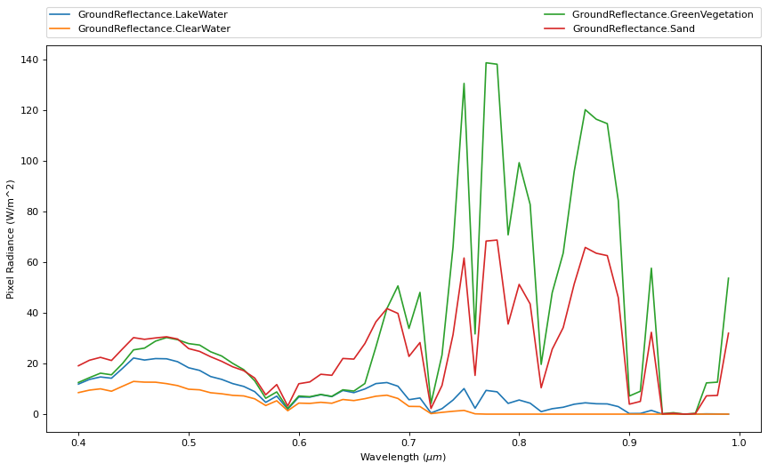

```python
print('Seteamos variables que se van a mantener constantes en la simulación')
#------------------------------------------------------------------------------
# Se especifica el tipo de aerosoles presentes
s.aero_profile = AeroProfile.PredefinedType(AeroProfile.Maritime)

# Se especifica el tipo de superficie
s.ground_reflectance = GroundReflectance.HomogeneousLambertian(GroundReflectance.LakeWater)
#s.ground_reflectance = GroundReflectance.HomogeneousOcean(5,5,10,10)

# No realizamos correcion atmosferica
s.atmos_corr = AtmosCorr.NoAtmosCorr()
#------------------------------------------------------------------------------


#==============================================================================
print('Configuramos la geometria del sensor, asi como su altura y la del\
 blanco')

# Geometria de observación del sensor
s.geometry.from_time_and_location(51.148, 0.307, "2022-05-23 10:00:00", 0, 10) # from_time_and_location(lat,long,datetimestring,view_z,view_a)

# Se especifica la altura del sensor
s.altitudes.set_sensor_satellite_level()

# Se especifica la altura del escenario
s.altitudes.set_target_sea_level()

#==============================================================================
print('Corremos el 6S haciendo variar los tipos de suelo predefinidos')

# se especifican los distintos tipos de suelo.
predifinedtype = [GroundReflectance.LakeWater , GroundReflectance.ClearWater , GroundReflectance.GreenVegetation , GroundReflectance.Sand ]
nameprofile = ['GroundReflectance.LakeWater' , 'GroundReflectance.ClearWater' , 'GroundReflectance.GreenVegetation ', 'GroundReflectance.Sand' ]
i = 0

for param in predifinedtype :
    print(nameprofile[i])
    s.ground_reflectance = GroundReflectance.HomogeneousLambertian(param)
    wavelengths, results = SixSHelpers.Wavelengths.run_wavelengths(s, np.arange(0.4, 1., 0.01), output_name='pixel_radiance')
    labels = nameprofile[i]
    print(nameprofile[i])
    plt.figure(4,figsize=(18*(.72), 10*(.72)), dpi= 80, facecolor='w', edgecolor='k')

    plt.plot(wavelengths, results,  label =labels )
    plt.legend(bbox_to_anchor=(0., 1.02, 1., .102), loc=3, ncol=2, mode="expand", borderaxespad=0.)
    plt.xlabel("Wavelength ($\mu m$)")
    plt.ylabel("Pixel Radiance (W/m^2)")
    i = i+1
plt.show()
```

Esto es radiancia no reflectancia, la vegetacion salta.

### Variación del perfil atmosférico

```
Seteamos variables que se van a mantener constantes en la simulación
Configuramos la geometria del sensor, asi como su altura y la del blanco
Corremos el modelo para los distintos perfiles atmosfericos
AtmosProfile.MidlatitudeSummer
Running for many wavelengths - this may take a long time
AtmosProfile.MidlatitudeSummer
AtmosProfile.Tropical
Running for many wavelengths - this may take a long time
AtmosProfile.Tropical
AtmosProfile.SubarcticWinter
Running for many wavelengths - this may take a long time
AtmosProfile.SubarcticWinter
```

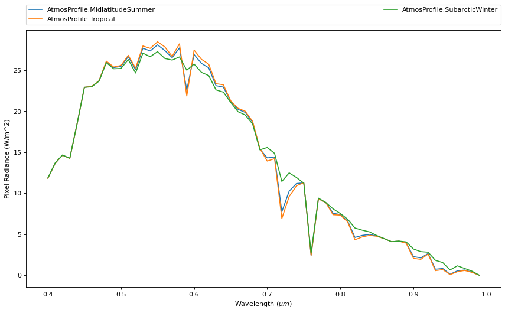

```python
print('Seteamos variables que se van a mantener constantes en la simulación')
#------------------------------------------------------------------------------
# Se especifica el tipo de aerosoles presentes
s.aero_profile = AeroProfile.PredefinedType(AeroProfile.Maritime)

# Se especifica el tipo de superficie
s.ground_reflectance = GroundReflectance.HomogeneousLambertian(GroundReflectance.LakeWater)
#s.ground_reflectance = GroundReflectance.HomogeneousOcean(5,5,10,10)

# No realizamos correcion atmosferica
s.atmos_corr = AtmosCorr.NoAtmosCorr()
#------------------------------------------------------------------------------


#==============================================================================
print('Configuramos la geometria del sensor, asi como su altura y la del\
 blanco')

# Geometria de observación del sensor
s.geometry.from_time_and_location(51.148, 0.307, "2022-05-23 10:00:00", 0, 10) # from_time_and_location(lat,long,datetimestring,view_z,view_a)

# Se especifica la altura del sensor
s.altitudes.set_sensor_satellite_level()

# Se especifica la altura del escenario
s.altitudes.set_target_sea_level()

#==============================================================================

print('Corremos el modelo para los distintos perfiles atmosfericos')

# Completar: especifique los distintos tipos de perfil de atmosfera.
predifinedtype = [AtmosProfile.MidlatitudeSummer,AtmosProfile.Tropical,AtmosProfile.SubarcticWinter]
nameprofile = ["AtmosProfile.MidlatitudeSummer","AtmosProfile.Tropical","AtmosProfile.SubarcticWinter"]
i = 0
for param in predifinedtype:
    print(nameprofile[i])
    s.atmos_profile = AtmosProfile.PredefinedType(param)
    wavelengths, results = SixSHelpers.Wavelengths.run_wavelengths(s, np.arange(0.4, 1., 0.01), output_name='pixel_radiance')

    labels = nameprofile[i]
    print(nameprofile[i])
    plt.figure(5,figsize=(18*(.72), 10*(.72)), dpi= 80, facecolor='w', edgecolor='k')
    plt.plot(wavelengths, results,  label =labels )
    plt.legend(bbox_to_anchor=(0., 1.02, 1., .102), loc=3, ncol=2, mode="expand", borderaxespad=0.)
    plt.xlabel("Wavelength ($\mu m$)")
    plt.ylabel("Pixel Radiance (W/m^2)")
    i = i+1
plt.show()
```

En el artico esta mas seco, porque hay menos vapor te agua, entonces identificamos clara linea de vapor de agua

### Variación del ángulo de observarción

```
Seteamos variables que se van a mantener constantes en la simulación
Configuramos la geometria del sensor, asi como su altura y la del blanco
Fijamos la posiciondel sol y del angulo azimutal del sensor
Fijamos la longitud de onda a 450 nm
Queremos estudiar como van a cambiar los distintos outputs de acuerdo a la posicion del sensor y ver a que situacion podemos llamar sunglint para ello vayamos cambiando la posicion del sensor con respecto al zenit y generemos distintas corridas del programa
Creemos el tipo de superficie que sea el oceano que ya tiene el modelo capaz de computar el sunglint
Running for many wavelengths - this may take a long time
outputs[i] <Py6S.outputs.Outputs object at 0x00000258C954D2E0>
Running for many wavelengths - this may take a long time
outputs[i] <Py6S.outputs.Outputs object at 0x00000258C9E2A700>
Running for many wavelengths - this may take a long time
outputs[i] <Py6S.outputs.Outputs object at 0x00000258C9E2A970>
Running for many wavelengths - this may take a long time
outputs[i] <Py6S.outputs.Outputs object at 0x00000258C9E2A550>
Running for many wavelengths - this may take a long time
outputs[i] <Py6S.outputs.Outputs object at 0x00000258C9E2ACD0>
Running for many wavelengths - this may take a long time
outputs[i] <Py6S.outputs.Outputs object at 0x00000258C9E2AE50>
Running for many wavelengths - this may take a long time
outputs[i] <Py6S.outputs.Outputs object at 0x00000258C9E2A370>
Running for many wavelengths - this may take a long time
outputs[i] <Py6S.outputs.Outputs object at 0x00000258C9E2ABE0>
Running for many wavelengths - this may take a long time
outputs[i] <Py6S.outputs.Outputs object at 0x00000258C9E2A460>
Running for many wavelengths - this may take a long time
outputs[i] <Py6S.outputs.Outputs object at 0x00000258C9E2A160>
Running for many wavelengths - this may take a long time
outputs[i] <Py6S.outputs.Outputs object at 0x00000258C9E2AD60>
Running for many wavelengths - this may take a long time
outputs[i] <Py6S.outputs.Outputs object at 0x00000258C9E2AF10>
Running for many wavelengths - this may take a long time
outputs[i] <Py6S.outputs.Outputs object at 0x00000258C9E2A070>
Running for many wavelengths - this may take a long time
outputs[i] <Py6S.outputs.Outputs object at 0x00000258C9E35B50>
Running for many wavelengths - this may take a long time
outputs[i] <Py6S.outputs.Outputs object at 0x00000258CA363940>
Running for many wavelengths - this may take a long time
outputs[i] <Py6S.outputs.Outputs object at 0x00000258C9E35490>
Running for many wavelengths - this may take a long time
outputs[i] <Py6S.outputs.Outputs object at 0x00000258CA4C6070>
```

[output cut: 11 more lines]

```
outputs[i] <Py6S.outputs.Outputs object at 0x00000258CA363280>
Running for many wavelengths - this may take a long time
outputs[i] <Py6S.outputs.Outputs object at 0x00000258CA363220>
Running for many wavelengths - this may take a long time
outputs[i] <Py6S.outputs.Outputs object at 0x00000258CA3637C0>
Running for many wavelengths - this may take a long time
outputs[i] <Py6S.outputs.Outputs object at 0x00000258CA363D90>
Running for many wavelengths - this may take a long time
outputs[i] <Py6S.outputs.Outputs object at 0x00000258CA363760>
Running for many wavelengths - this may take a long time
outputs[i] <Py6S.outputs.Outputs object at 0x00000258CA3635B0>
Running for many wavelengths - this may take a long time
outputs[i] <Py6S.outputs.Outputs object at 0x00000258CA3636D0>
Running for many wavelengths - this may take a long time
outputs[i] <Py6S.outputs.Outputs object at 0x00000258CA363670>
```

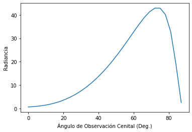

```python
print('Seteamos variables que se van a mantener constantes en la simulación')
#------------------------------------------------------------------------------
# Se especifica el tipo de aerosoles presentes
s.aero_profile = AeroProfile.PredefinedType(AeroProfile.Maritime)

# Se especifica el tipo de superficie (en este caso marina)
s.ground_reflectance  = GroundReflectance.HomogeneousOcean(15,0,34,0.05) # HomogeneousOcean(wind_speed, wind_azimuth, salinity, pigment_concentration)

# No realizamos correcion atmosferica
s.atmos_corr = AtmosCorr.NoAtmosCorr()
#------------------------------------------------------------------------------

#==============================================================================
print('Configuramos la geometria del sensor, asi como su altura y la del\
 blanco')

# Geometria de observación del sensor
s.geometry.from_time_and_location(51.148, 0.307, "2022-05-23 10:00:00", 0, 10) # from_time_and_location(lat,long,datetimestring,view_z,view_a)

# Se especifica la altura del sensor
s.altitudes.set_sensor_satellite_level()

# Se especifica la altura del escenario
s.altitudes.set_target_sea_level()

#==============================================================================

print('Fijamos la posiciondel sol y del angulo azimutal del sensor')
s.geometry = Geometry.User()
s.geometry.view_a = 0
s.geometry.solar_z= 60
s.geometry.solar_a = 180

print('Fijamos la longitud de onda a 450 nm')
s.wavelength = Wavelength(0.450)


print('Queremos estudiar como van a cambiar los distintos outputs de acuerdo \
a la posicion del sensor y ver a que situacion podemos llamar sunglint para \
ello vayamos cambiando la posicion del sensor con respecto al zenit y generemos \
distintas corridas del programa')


print('Creemos el tipo de superficie que sea el oceano que ya tiene el modelo \
capaz de computar el sunglint')


# Creo un vector que contenga todos las keys del diccionario
key_vector = ['version', 'month', 'day', 'solar_z', 'solar_a', 'view_z', 'view_a', 'scattering_angle',
              'azimuthal_angle_difference', 'visibility', 'aot550',
              'ground_pressure', 'ground_altitude', 'apparent_reflectance', 'apparent_radiance',
              'total_gaseous_transmittance', 'wv_above_aerosol', 'wv_mixed_with_aerosol',
              'wv_under_aerosol', 'percent_direct_solar_irradiance', 'percent_diffuse_solar_irradiance',
              'percent_environmental_irradiance', 'atmospheric_intrinsic_reflectance',
              'background_reflectance', 'pixel_reflectance', 'direct_solar_irradiance',
              'diffuse_solar_irradiance', 'environmental_irradiance', 'atmospheric_intrinsic_radiance',
              'background_radiance', 'pixel_radiance', 'solar_spectrum']

vector_output = np.arange(len(key_vector))
vector_output = vector_output * 0.

# Creaamos vector de variación del ángulo cenital entre 0 y 90° en pasos de 3°
angulos_cenital_sensor = np.arange(0,90,3)

# Inicializamos variable a estudiar
pixel_radiance = []
# apparent_radiance=[]

for i in angulos_cenital_sensor:
    s.geometry.view_z = i
    wavelengths, outputs = SixSHelpers.Wavelengths.run_wavelengths(s, np.arange(0.700,0.701))

    #Corremos el bucle para ir sacando los valores del diccionario values y
    #transformarlo en vectores y guardarlos en el archivo
    for i in range(len(wavelengths)):
        objeto_output = outputs[i]
        print('outputs[i]', outputs[i])
        pixel_radiance.append(objeto_output.values['pixel_radiance'])
#         apparent_radiance.append(objeto_output.values['apparent_radiance'])

plt.figure(6)
plt.plot(angulos_cenital_sensor , pixel_radiance )
plt.xlabel("Ángulo de Observación Cenital (Deg.)")
plt.ylabel("Radiancia")
plt.show()
```

Cuanto más perpendicular se encuentra el sol con respecto a la superficie terrestre (es decir, cuanto menor valor del ángulo cenital) menor es el camino que recorre la radiación solar a través de la atmósfera.